# COVID19 Dataset

This dataset is publically avaliable and hosted by google is a very consumable format. More information about all the different statistics can be found here: https://health.google.com/covid-19/open-data

## Modeling

During the course of modeling the cases and deaths, we want to understand what models will work best. Starting from simple LinearRegression and ending up with a more complex model like ElasticNet.

The main goal is to understand if we can model new cases over time and predict the number of new cases in the future given the features.

```python
import warnings
from sklearn.exceptions import ConvergenceWarning

# disable future,user,depreciation warnings
warnings.simplefilter(action='ignore', category=FutureWarning)
warnings.simplefilter(action='ignore', category=UserWarning)
warnings.simplefilter(action='ignore', category=DeprecationWarning)
warnings.simplefilter(action='ignore', category=RuntimeWarning)
warnings.simplefilter(action='ignore', category=ConvergenceWarning)

import os
import pandas as pd
import seaborn as sns
import geopandas as gpd
import matplotlib.pyplot as plt

sns.set_theme(style="whitegrid")
```

```python
if os.path.exists("data.csv"):
    df = pd.read_csv("data.csv")
else:
    df = pd.read_csv("https://storage.googleapis.com/covid19-open-data/v3/location/US.csv")
    df.to_csv("data.csv")
```

```python
columns = [
    'date',
    'new_confirmed',
    'new_deceased',
    'new_tested',
    'new_hospitalized_patients',
    'new_intensive_care_patients',
    'new_ventilator_patients',
    'new_persons_vaccinated',
    'new_persons_fully_vaccinated'
]

df = df[columns]

df.date = pd.to_datetime(df.date)

df['breakout'] = df.date - df.date.min()
df['breakout'] = df['breakout'].dt.days

# set nan values with the last valid observation or 0
df = df.fillna(method='ffill').fillna(0)

df.info()

df.head()
```

```
<class 'pandas.core.frame.DataFrame'>
RangeIndex: 991 entries, 0 to 990
Data columns (total 10 columns):
 #   Column                        Non-Null Count  Dtype
---  ------                        --------------  -----
 0   date                          991 non-null    datetime64[ns]
 1   new_confirmed                 991 non-null    float64
 2   new_deceased                  991 non-null    float64
 3   new_tested                    991 non-null    float64
 4   new_hospitalized_patients     991 non-null    float64
 5   new_intensive_care_patients   991 non-null    float64
 6   new_ventilator_patients       991 non-null    float64
 7   new_persons_vaccinated        991 non-null    float64
 8   new_persons_fully_vaccinated  991 non-null    float64
 9   breakout                      991 non-null    int64
dtypes: datetime64[ns](1), float64(8), int64(1)
memory usage: 77.5 KB
```

|  | date | new_confirmed | new_deceased | new_tested | new_hospitalized_patients | new_intensive_care_patients | new_ventilator_patients | new_persons_vaccinated | new_persons_fully_vaccinated | breakout |
| --- | --- | --- | --- | --- | --- | --- | --- | --- | --- | --- |
| 0 | 2020-01-01 | 0.0 | 0.0 | 0.0 | 0.0 | 0.0 | 0.0 | 0.0 | 0.0 | 0 |
| 1 | 2020-01-02 | 0.0 | 0.0 | 0.0 | 0.0 | 0.0 | 0.0 | 0.0 | 0.0 | 1 |
| 2 | 2020-01-03 | 0.0 | 0.0 | 0.0 | 0.0 | 0.0 | 0.0 | 0.0 | 0.0 | 2 |
| 3 | 2020-01-04 | 0.0 | 0.0 | 0.0 | 0.0 | 0.0 | 0.0 | 0.0 | 0.0 | 3 |
| 4 | 2020-01-05 | 0.0 | 0.0 | 0.0 | 0.0 | 0.0 | 0.0 | 0.0 | 0.0 | 4 |

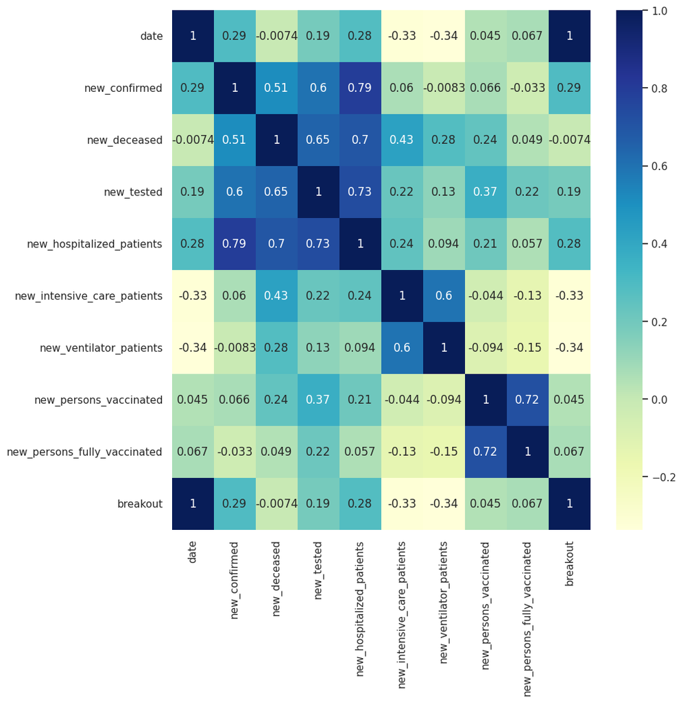

```python
# correlation matrix
plt.figure(figsize=(10, 10))
sns.heatmap(df.corr(), annot=True, cmap="YlGnBu")
```

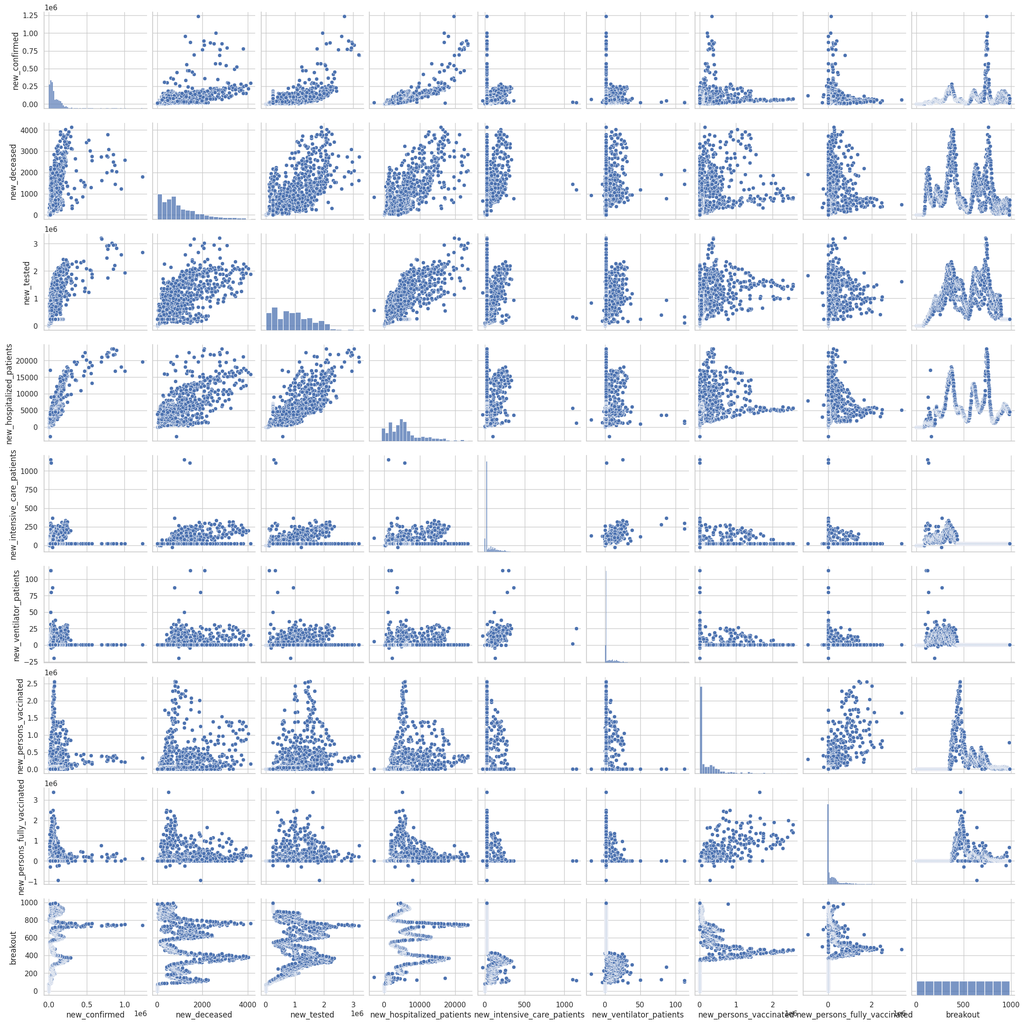

```python
sns.pairplot(df)
```

A couple of interesting correlations to speculate on. We see that there is a signficant positive correlation between the number of hospitalization and deaths. Also, there is a positive correlation between hostpitalizations and confirmed cases and tests. Of course, this is not a causation, but it is interesting to see that there is a correlation between these features.

## Modeling!

We will start with the most basic modeling, and then move on to more complex models, throwing in polynomial features along the way if needed. We will be using the following models:

- LinearRegression
- Ridge
- Lasso
- ElasticNet

```python
from sklearn.linear_model import LinearRegression, Ridge, Lasso, ElasticNet
from sklearn.model_selection import train_test_split
from sklearn.metrics import mean_squared_error, r2_score
from sklearn.preprocessing import PolynomialFeatures
from sklearn.pipeline import Pipeline
from sklearn.preprocessing import StandardScaler, MinMaxScaler
from sklearn.model_selection import GridSearchCV
from sklearn.feature_selection import RFECV
```

```python
x = df[[col for col in df.columns if col != 'new_confirmed' and col != 'date']]
y = df['new_confirmed']

x_train, x_test, y_train, y_test = train_test_split(x, y, test_size=0.2)

r2_scores = {}
```

```
Model R^2: 0.6148192681133351
```

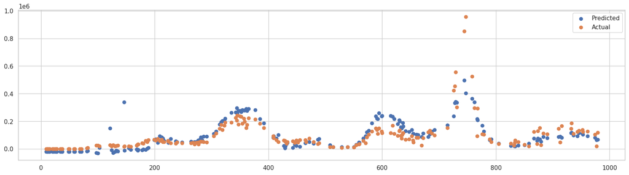

```python
model = LinearRegression()

model.fit(x_train, y_train)

y_pred = model.predict(x_test)

score = r2_score(y_test, y_pred)

print(f"Model R^2: {score}")

r2_scores['linear'] = score

# plot predictions vs actual
plt.figure(figsize=(20, 5))
plt.scatter(x_test.breakout, y_pred)
plt.scatter(x_test.breakout, y_test)
plt.legend(labels=["Predicted", "Actual"])
```

With simple LinearRegression, we typically find R^2 values between 0.5 and 0.7. This will be a good metric to utilize when comparing future models but the best guess is that this model is underfitting.

```
Best Score: 0.8604017968416097
Best Params: {'poly__degree': 2}
```

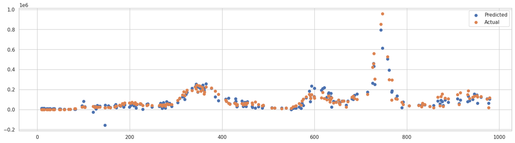

```python
model = Pipeline([
    ('poly', PolynomialFeatures()),
    ('model', LinearRegression())
])

params = {
    'poly__degree': [1, 2, 3, 4, 5],
}

search = GridSearchCV(model, params, cv=5, scoring='r2', n_jobs=-1)

search.fit(x_train, y_train)

best_model = search.best_estimator_
best_params = search.best_params_
best_score = search.best_score_

print(f"Best Score: {best_score}")
print(f"Best Params: {best_params}")

r2_scores['polylinear'] = best_score

y_pred = best_model.predict(x_test)

# plot predictions vs actual
plt.figure(figsize=(20, 5))
plt.scatter(x_test.breakout, y_pred)
plt.scatter(x_test.breakout, y_test)
plt.legend(labels=["Predicted", "Actual"])
```

```
Best Score: 0.8878717762645195
Best Params: {'model__alpha': 0.1, 'poly__degree': 3}
```

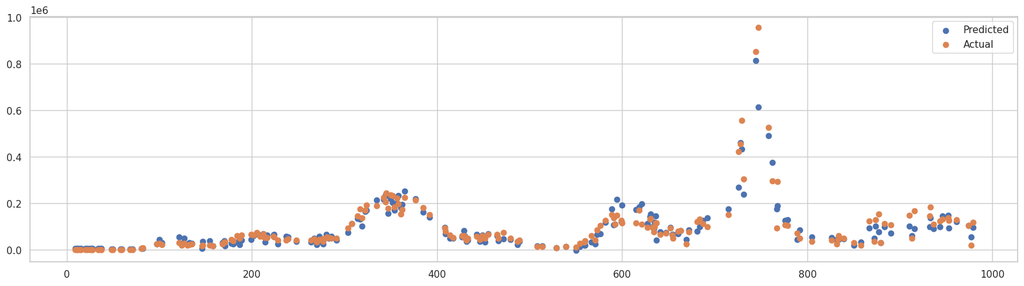

```python
model = Pipeline([
    ('poly', PolynomialFeatures()),
    ('scaler', MinMaxScaler()),
    ('model', Ridge())
])

params = {
    'poly__degree': [1, 2, 3, 4, 5],
    'model__alpha': [0.1, 0.5, 1, 2, 5, 10, 20, 50, 100]
}

search = GridSearchCV(model, params, cv=5, scoring='r2', n_jobs=-1)

search.fit(x_train, y_train)

best_model = search.best_estimator_
best_params = search.best_params_
best_score = search.best_score_

print(f"Best Score: {best_score}")
print(f"Best Params: {best_params}")

r2_scores['polyridge'] = best_score

y_pred = best_model.predict(x_test)

# plot predictions vs actual
plt.figure(figsize=(20, 5))
plt.scatter(x_test.breakout, y_pred)
plt.scatter(x_test.breakout, y_test)
plt.legend(labels=["Predicted", "Actual"])
plt.show()
```

With ridge regression, we see a major improvement. Adding regularization certainly seemed to help. In addition, some polynomial features included were better than none. The best estimator had a R^2 value of 0.89.

```
Best Score: 0.6684711441421003
Best Params: {'model__alpha': 100}
Model Coefficients: [     -0.           69726.29836806  549692.71633038 -235830.42772072
  -29252.14225937  -94295.30754802  -24356.24698644       0.        ]
```

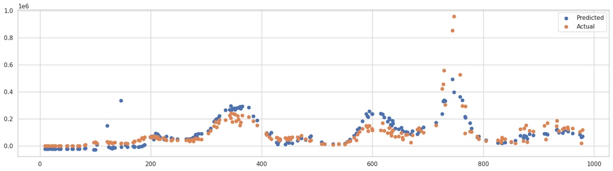

```python
model = Pipeline([
    #('poly', PolynomialFeatures()),
    # we will leave out polynomial features for now
    # so we can see if any features are not important
    ('scaler', MinMaxScaler()),
    ('model', Lasso())
])

params = {
    #'poly__degree': [1, 2, 3, 4, 5],
    'model__alpha': [0.1, 0.5, 1, 2, 5, 10, 20, 50, 100]
}

search = GridSearchCV(model, params, cv=5, scoring='r2', n_jobs=-1)

search.fit(x_train, y_train)

best_model = search.best_estimator_
best_params = search.best_params_
best_score = search.best_score_

print(f"Best Score: {best_score}")
print(f"Best Params: {best_params}")
print(f"Model Coefficients: {best_model['model'].coef_}")

r2_scores['lasso'] = best_score

y_pred = best_model.predict(x_test)

# plot predictions vs actual
plt.figure(figsize=(20, 5))
plt.scatter(x_test.breakout, y_pred)
plt.scatter(x_test.breakout, y_test)
plt.legend(labels=["Predicted", "Actual"])
plt.show()
```

```
Best Score: 0.8951442817507843
Best Params: {'model__alpha': 50, 'poly__degree': 4}
Model Coefficients: 495
Total Zeroed Coefficients: 457
```

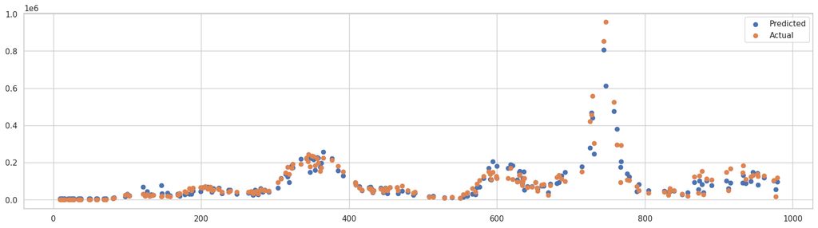

```python
model = Pipeline([
    ('poly', PolynomialFeatures()),
    ('scaler', MinMaxScaler()),
    ('model', Lasso())
])

params = {
    'poly__degree': [1, 2, 3, 4, 5],
    'model__alpha': [0.1, 0.5, 1, 2, 5, 10, 20, 50, 100]
}

search = GridSearchCV(model, params, cv=5, scoring='r2', n_jobs=-1)

search.fit(x_train, y_train)

best_model = search.best_estimator_
best_params = search.best_params_
best_score = search.best_score_

print(f"Best Score: {best_score}")
print(f"Best Params: {best_params}")
print(f"Model Coefficients: {len(best_model['model'].coef_)}")
print(f"Total Zeroed Coefficients: {len([coef for coef in best_model['model'].coef_ if coef == 0])}")

r2_scores['polylasso'] = best_score

y_pred = best_model.predict(x_test)

# plot predictions vs actual
plt.figure(figsize=(20, 5))
plt.scatter(x_test.breakout, y_pred)
plt.scatter(x_test.breakout, y_test)
plt.legend(labels=["Predicted", "Actual"])
plt.show()
```

```
Best Score: 0.8951442817507843
Best Params: {'model__alpha': 50, 'model__l1_ratio': 1, 'poly__degree': 4}
Model Coefficients: 495
Total Zeroed Coefficients: 457
```

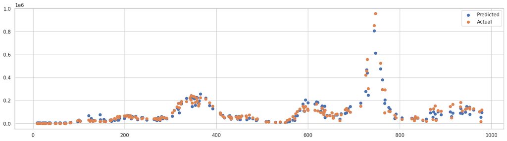

```python
model = Pipeline([
    ('poly', PolynomialFeatures()),
    ('scaler', MinMaxScaler()),
    ('model', ElasticNet())
])

params = {
    'poly__degree': [1, 2, 3, 4, 5],
    'model__alpha': [0.1, 0.5, 1, 2, 5, 10, 20, 50, 100],
    'model__l1_ratio': [0.1, 0.5, 1, 2, 5, 10, 20, 50, 100]
}

search = GridSearchCV(model, params, cv=5, scoring='r2', n_jobs=-1)

search.fit(x_train, y_train)

best_model = search.best_estimator_
best_params = search.best_params_
best_score = search.best_score_

print(f"Best Score: {best_score}")
print(f"Best Params: {best_params}")
print(f"Model Coefficients: {len(best_model['model'].coef_)}")
print(f"Total Zeroed Coefficients: {len([coef for coef in best_model['model'].coef_ if coef == 0])}")

r2_scores['polyelastic'] = best_score

y_pred = best_model.predict(x_test)

# plot predictions vs actual
plt.figure(figsize=(20, 5))
plt.scatter(x_test.breakout, y_pred)
plt.scatter(x_test.breakout, y_test)
plt.legend(labels=["Predicted", "Actual"])
plt.show()
```

Finally, when applying ElasticNet, we see that the best score is around ~0.89. With this model, we have almost exactly the same parameters as the Lasso model. This may indicate we are dealing with too complex of a model and could probably get away with a simpler model.

```
best models:  [('polylasso', 0.8951442817507843), ('polyelastic', 0.8951442817507843), ('polyridge', 0.8878717762645195)]
```

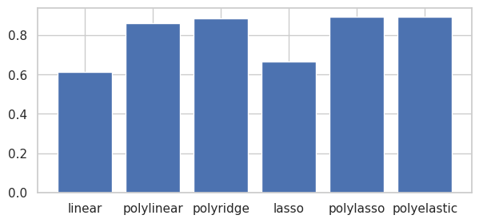

```python
# plot r2 scores
plt.figure(figsize=(7, 3))
plt.bar(r2_scores.keys(), r2_scores.values())

print('best models: ', sorted(r2_scores.items(), key=lambda x: x[1], reverse=True)[:3])
```

# Conclusion

With this anaylsis, our top models performed at almost 90% accuracy (0.89 R^2). We choose the top features that, intiutively, make sense that would be correlated. Looking at the pairplot, we see heavy coorelation between the features. But, in the dataset itself there are many more features we could anaylze. Perhaps using search trends or location data could help as the virus did spread from location to location over time.

We may not even be looking at all the data we need to anaylze. COVID19 did come from overseas before it came to the US mainland. Perhaps looking at the data from other countries could help us predict the spread of the virus in the US. Flight data may also even be useful in this case.